# Investigation of Strava Personal Fitness Data

## by Daniel Mayer

## Investigation Overview

In this investigation, I aim to understand trends in key running fitness variables (heart rate, pace, distance, and cadence) that influence how my overall fitness has changed over time.

## Dataset Overview

The data consisted up a bulk download from Strava of my 500+ fitness activities logged since 2018, including attributes such as sport, date, time, distance, speed, cadence and heart rate.

### *Click the down arrow to see visualizations on each page*

## Number of Activities by Sport

I went from being a balanced triathlete in 2019 to more of a runner during the pandemic in 2020. Good news is my the total number of annual activities is trending upward, nearly eclipsing 250 in 2020.

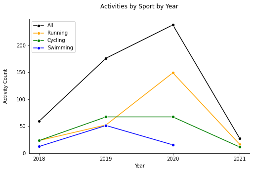

## Distribution of Running Cadence

Up until summer 2020, I was primarily a low cadence running, with my typical average steps per minute hovering around 160. However, I consciously changed that strategy in 2020, which is why the overall distribution has built up a larger right tail in the mid 170s.

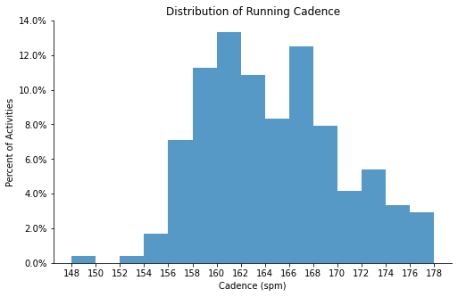

## Heart Rate vs Pace Across Cadence Classes

I classified cadence values as either Low(< 160spm), Medium (160-168spm), or High (> 168spm) and labelled each activity on a plot of heart rate versus pace. A higher cadence is directly related to an increased average heart rate and faster pace. This is particularly true with the "High" cadence activities. There are no purple data points slower than about 6:00/km and with an average heart rate lower than 130. logically it makes sense, as the body needs to work harder but in turn will go faster if the legs are turning over more quickly.

Right now there is also not a lot of different in pace between my medium and high cadence runs. This may change after a few more months of high-cadence training.

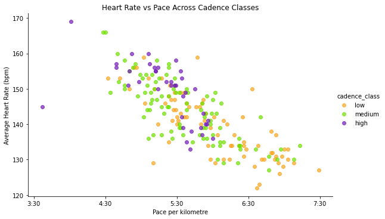

## Distribution of Relative Effort

Relative Effort is a metric Strava calculates to determine how difficult an individual activity was compared to a baseline. Given the right skew, I used a logarithmic scale to plot the distribution. There is a peak in relative effort between 30-40, which appears to be a common effort level for my workouts.

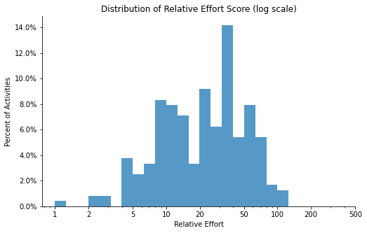

## Heart Rate vs Distance Across Relative Effort Classes

Liek with cadence, I created classes of Relative Effort values to try and uncover trends. I classified relative effort values as either Low(< 20), Medium (20-50), or High (> 50). Heart Rate and Distance were two of the factors that correlated highest with relative effort.

The class distinction is much more clear for Relative Effort than it was with cadence. As distance and heart rate increase, so does relative effort. Heart Rate appears to have an especially large impact, as the high Relative Effort activities are slightly shifted up on the chart.

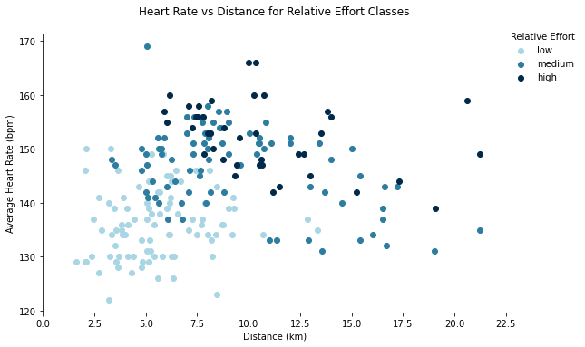

## Running Volume over Time (30 Day Moving Average)

The 30 day average smooths out day to day fluctuations in the data and clearly shows the periods of time when I was running consistently. The blue highlights appear on dates where my running distance in the previous 30 days was greater than 120km (an arbitrary threshold I try and target).

It's not surprising that 2020 was my most consistent running year, given my focus on longer, slower runs and the lack of swim workouts with pools closed due to the pandemic.

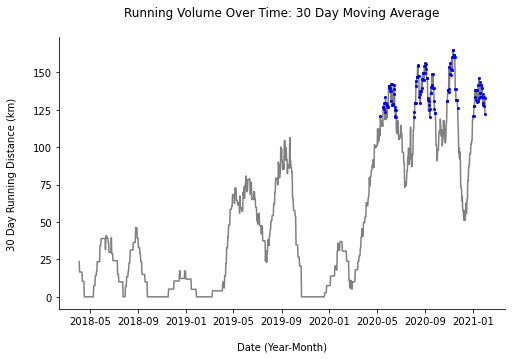

## Fitness Level over Time

For this analysis, I created a simplistic "Fitness Score" ratio as a normalized way to compare how well I performed in each activity. The score is a ratio of Speed / Average Heart Rate multiplied by 100. A higher value indicates greater fitness. I am assuming that a lower heart rate and/or a higher speed are associated with higher fitness. I recognize that this is not nearly as robust as something like VO2 Max, but it does factor in distance and time, as they are used to calculate speed.

On a first look at this simplistic metric over time, you might conclude that I am not getting much fitter over time. However, as this is my own personal data, I know there are other factors that may not be reflected here. For instance, I recently started training at a higher cadence, which boosts up heart rate without the immediate corresponding payoff in speed. I also tend to battle a lot of injuries in peak season and slack off a bit in the fall/winter. Finally, my wrist heart rate sensor is sometimes inaccurate which can lead to some inaccurate results and artificial inflation or deflation of certain months.

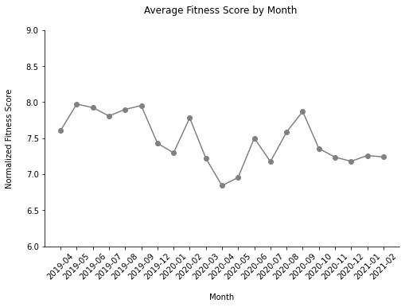